# **Projeto LabEst: Consultoria em Análise Estatística para Alunos de Pós-Graduação**

### **Relatório Preliminar da Análise Estatística:**

### Literacia Familiar no período pré e pandêmico de Covid-19: cenário brasileiro e estratégias de intervenção

##### **Cliente**:

##### Natália Viana

##### Doutoranda em Psicologia: Cognição e Comportamento - Faculdade de Filosofia e Ciências Humanas da Universidade Federal de Minas Gerais

##### **Consultores**

##### Bianca Caravelli de Sá

##### Luiz Felipe Avelar

##### Thomás de Santiago Silva

##### Alunos da Disciplina “Laboratório de Estatística I”

##### **Orientação: Prof. Adrian Luna**

##### **15/07/2022**

## 1) **Introdução e metodologia**

O objetivo dessa tese de doutorado é investigar o impacto da pandemia de COVID-19 nas práticas e recursos de literacia familiar no contexto brasileiro, ou seja, investigar as práticas de leitura e letramento feitas por pais e responsáveis com crianças pequenas feitas em casa durante o período de quarentena e o impacto para o desenvolvimento da alfabetização dessas crianças em um momento em que as escolas encontravam-se fechadas.

Para a obtenção dos dados, foi aplicado o questionário “Examinando a influência das restrições da COVID-19 no ambiente de literacia familiar” que consiste em perguntas de interesse que descrevem o perfil demográfico e socioeconômico dessas famílias, assim como os hábitos e atividades de literacia desenvolvidas no ambiente familiar.

A partir desses dados obtidos no questionário, as análises do dados encontram-se divididas em duas partes, a primeira consiste em uma análise descritiva, através de gráficos de barra, histogramas, boxplots e tabelas de frequência, das váriaveis de interesse principal que podem impactar os hábitos de literacia durante a pandemia. Cada variável foi analisada de maneira individual, sendo elas:

- Região de residência
- Raça
- Nível educacional do respondente
- Nível Socioeconômico da família - renda familiar
- Situação profissional do respondente antes e depois da covid
- Quantidade de cuidadores
- Quantidade de crianças
- Tipo de quarentena
- Nível de estresse com o isolamento

Já a segunda parte consiste em análises fatorial exploratórias a partir de blocos de perguntas a fim de reduzir a quantidade de variávies e obter indíces que explicam a variabilidade dos dados. As variáveis de interesse para essa análise foram divididas nos seguintes blocos:

- Bloco 1 - Bloco Reading History Br (Histórico de alfabetização)
- Bloco 2 - Home Literacy Resources Br (Recursos)
- Bloco 3 - Enrichment Activities Br (Atividades de enriquecimento)

## 2) **Resultados**

## 3) **Análise Exploratória**

### **Região de residência**

Pode-se observar que a grande maioria, 73,45%, das pessoas que respoderam ao questionário moram na região Sudeste do Brasil, enquanto que apenas 2,55% são residentes da região Centro-Oeste. Esta variável possui 931 observações NAs.

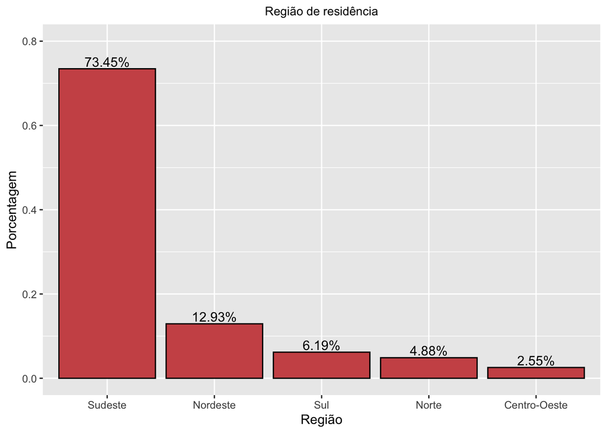

Figura 1 - Região de residência

### **Raça**

Pode-se observar que 87,92% das crianças são brancas ou pardas, sendo a raça branca a mais frequente. Para esta variável houve 931 obervações NAs.

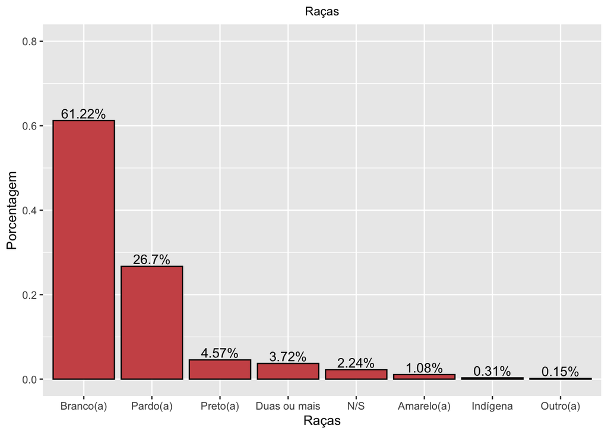

Figura 2 - Raça

### **Nível educacional do respondente**

Pode-se observar que a maioria dos respondentes do questionário possuem um nível educacional alto, sendo que 51,55% possuem pós-graduação, enquanto que apenas 1,01% dos respondentes possuiem Ensino Fundamental completo ou incompleto.

Vale ressaltar que 931 pessoas não responderam a essa pergunta.

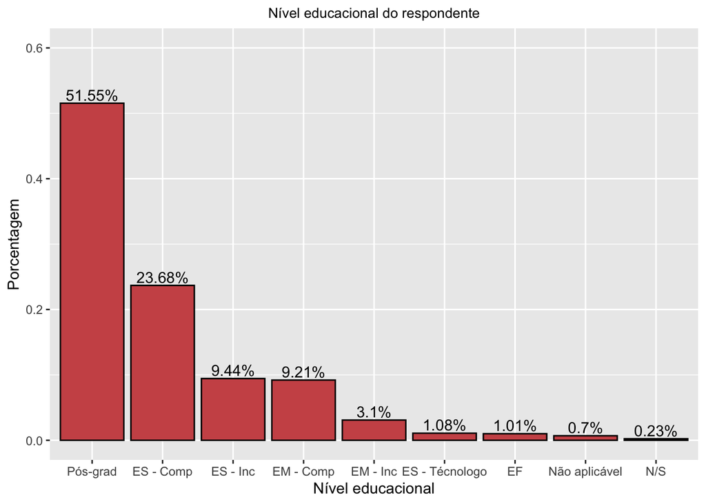

Figura 3 - Nível educacional do respondente

### **Nível Socioeconômico da família - Renda familiar**

Em relação a renda familiar, pode-se observar que possui uma distribuição com consideráveis valores outliers, os gráficos abaixo possuem duas versões, sendo a primeira os valores originais e a segunda removendo os outliers. A renda mediana familiar é de R$ 7000,00 e 978 pessoas não responderam a essa questão.

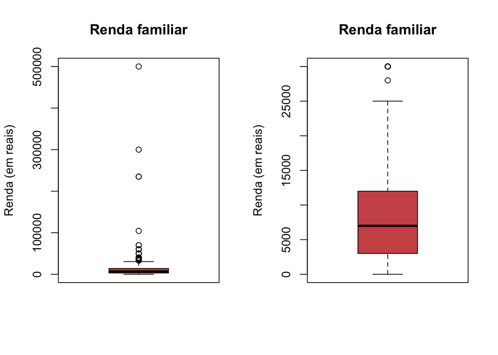

Figura 4 - Renda familiar

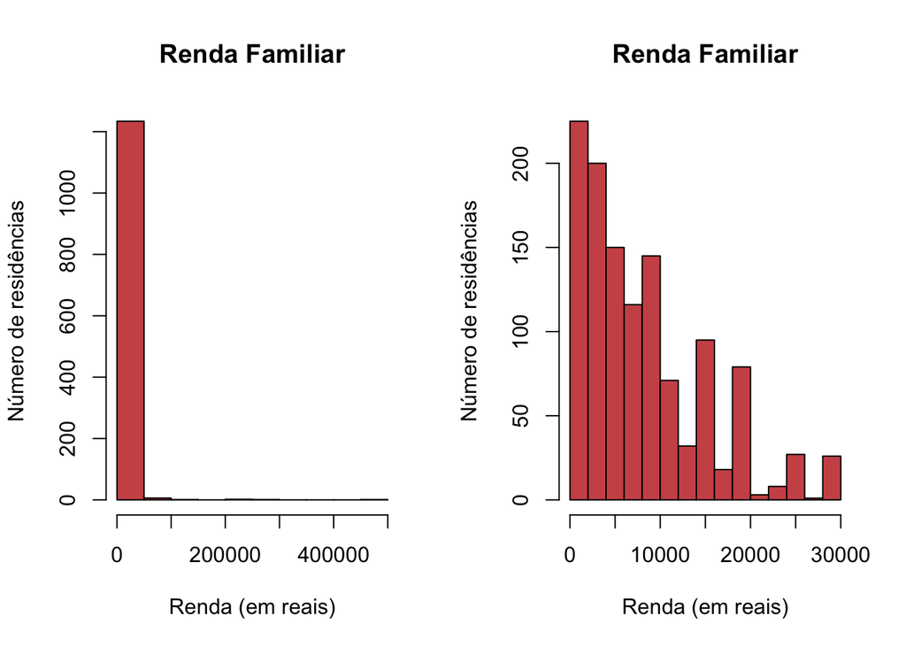

Figura 5 - Renda familiar

### **Situação profissional do respondente antes e depois da covid**

Para as duas questões sobre situação profissional, há 12 opções de resposta, sendo elas:

0 - Eu trabalhava em tempo integral fora de casa (mais do que 40 horas por semana)

1 - Eu trabalhava em tempo integral em casa (mais do que 40 horas por semana)

2 - Eu trabalhava em tempo integral, parcialmente em casa e parcialmente fora de casa (mais do que 40 horas por semana)

3 - Eu trabalhava meio período fora de casa (menos que 40 horas por semana)

4 - Eu trabalhava meio período em casa (menos que 40 horas por semana)

5 - Estudante

6 - Eu estava em licença de trabalho temporária (por exemplo suspenso do trabalho, licença maternidade)

7 - Era dono(a) de casa ou cuidava das crianças em tempo integral

8 - Desempregado

9 - Aposentado

10 - Beneficiário do INSS

11 - Prefiro não responder

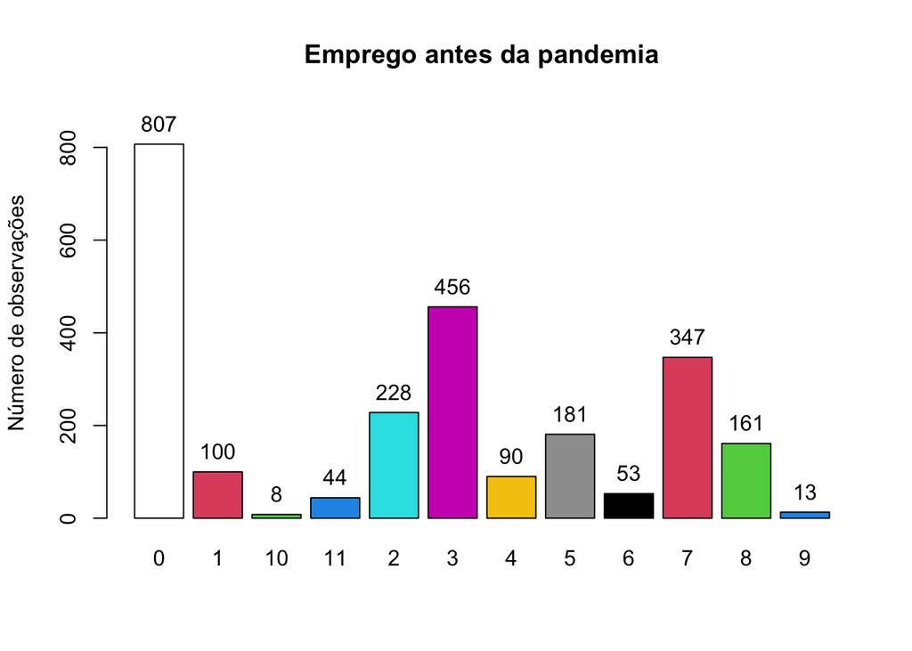

Figura 6 - Emprego pré pandemia

```
## job_before :
##         Frequency Percent Cum. percent
## 0             807   32.44        32.44
## 1             100    4.02        36.45
## 10              8    0.32        36.78
## 11             44    1.77        38.55
## 2             228    9.16        47.71
## 3             456   18.33        66.04
## 4              90    3.62        69.65
## 5             181    7.27        76.93
## 6              53    2.13        79.06
## 7             347   13.95        93.01
## 8             161    6.47        99.48
## 9              13    0.52       100.00
##   Total      2488  100.00       100.00
```

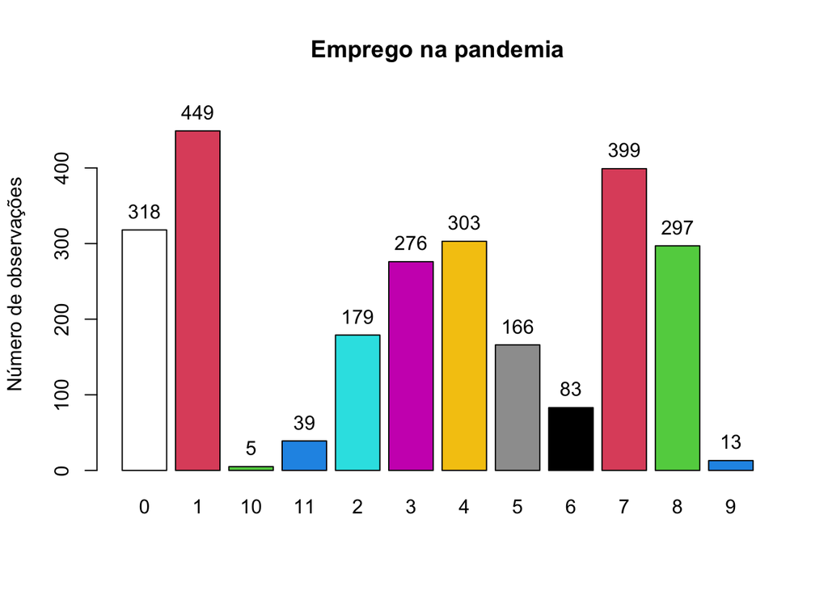

Figura 7 - Emprego na pandemia

```
## job_after :
##         Frequency Percent Cum. percent
## 0             318   12.58        12.58
## 1             449   17.77        30.35
## 10              5    0.20        30.55
## 11             39    1.54        32.09
## 2             179    7.08        39.18
## 3             276   10.92        50.10
## 4             303   11.99        62.09
## 5             166    6.57        68.66
## 6              83    3.28        71.94
## 7             399   15.79        87.73
## 8             297   11.75        99.49
## 9              13    0.51       100.00
##   Total      2527  100.00       100.00
```

### **Quantidade de cuidadores**

Pode-se observar que das 2223 respostas ao questionário, 2085 respostas foram de residências que possuem cuidadores.

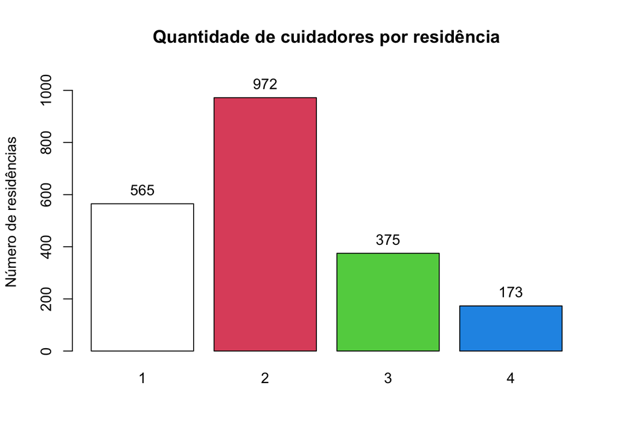

Figura 8 - Quantidade de cuidadores

```
## Quantidade_de_cuidadores :
##         Frequency Percent Cum. percent
## 1             565   27.10        27.10
## 2             972   46.62        73.72
## 3             375   17.99        91.70
## 4             173    8.30       100.00
##   Total      2085  100.00       100.00
```

### **Quantidade de crianças**

Pode-se observar que a maioria das residências possuem duas ou menos crianças, sendo que apenas 48 delas possuem quatro ou mais crianças. Para esta variável há 47 observações NAs.

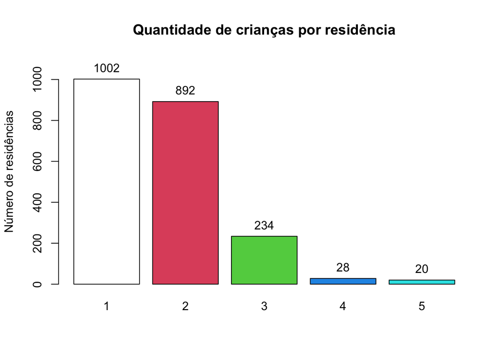

Figura 9 - Quantidade de crianças

```
## Quantidade_de_criancas :
##         Frequency Percent Cum. percent
## 1            1002   46.05        46.05
## 2             892   40.99        87.04
## 3             234   10.75        97.79
## 4              28    1.29        99.08
## 5              20    0.92       100.00
##   Total      2176  100.00       100.00
```

### **Tipo de quarentena**

Para o tipo de quarentena e restrições recomendadas à família, temos as seguintes opções:

0 - Não há restrições agora

1 - Quarentena voluntária

2 - Pedido ou aviso depermanência em casa pelo governo local (caminhadas ou passeios com distanciament osocial permitidos)

3 - Pedido de permanência em casa pelo governo local (só saia de casa para fins essenciais)

4 - Outro

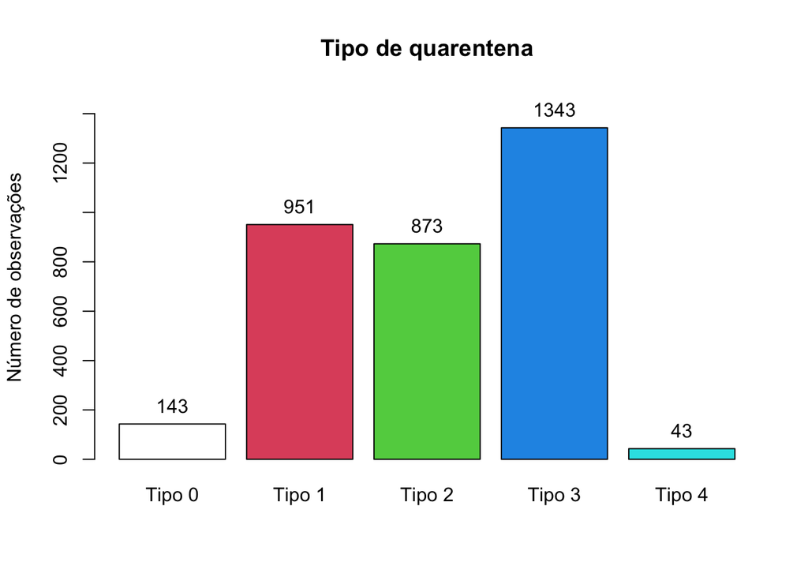

Figura 10 - Restrições familiares na pandemia

```
## restrictions :
##         Frequency Percent Cum. percent
## Tipo 0        143    4.26         4.26
## Tipo 1        951   28.36        32.63
## Tipo 2        873   26.04        58.66
## Tipo 3       1343   40.05        98.72
## Tipo 4         43    1.28       100.00
##   Total      3353  100.00       100.00
```

### **Nível de estresse com o isolamento**

Para o nível de estresse com o isolamento, tem-se as seguintes categorias:

0 - Não tem - Não tem sido estressante

1 - Pouco - Um pouco estressante

2 - Estressante - Estressante

3 - Muito - Muito estressante

4 - Extremamente - Extremamente estressante

Pode-se notar que apenas 175 das respostas consideram que o isolamento não tem sido estressante, enquanto 712 o consideram pouco estressante.

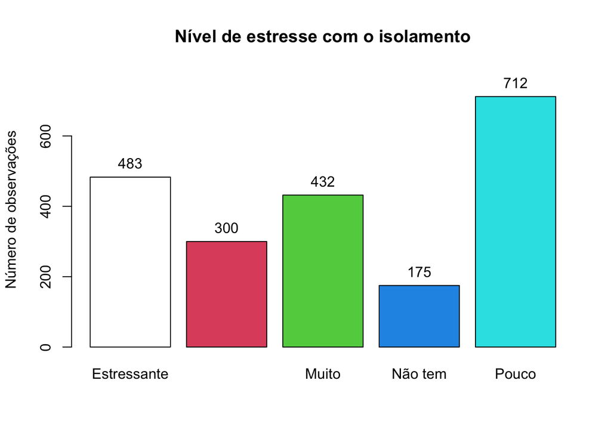

Figura 11 - Nível de estresse com o isolamento

```
## stress :
##              Frequency Percent Cum. percent
## Estressante        483   22.98        22.98
## Extremamente       300   14.27        37.25
## Muito              432   20.55        57.80
## Não tem            175    8.33        66.13
## Pouco              712   33.87       100.00
##   Total           2102  100.00       100.00
```

## 4) **Análise Fatorial - PCA e MCA**

Ao trabalhar com um grande número de variáveis, a matriz de correlação agrupa uma grande quantidade de coeficientes (190 coeficientes para K = 20 variáveis). É, portanto, essencial ter uma ferramenta capaz de resumir as principais relações entre as variáveis de forma visual.

O objetivo do **PCA** é tirar conclusões das relações lineares entre variáveis detectando as dimensões principais de variabilidade. Como será analisado, estas conclusões serão complementadas pela definição das variáveis sintéticas oferecidas pelo PCA. Portanto, será mais fácil descrever os dados usando algumas variáveis sintéticas em vez de todas as variáveis originais.

Assim como na análise de componentes principais (PCA), o objetivo é resumir as relações entre as variáveis. Essas relações são estudadas em pares ou todas juntas. Neste último caso, procuramos variáveis sintéticas que resumem as informações contidas em um número de variáveis. A informação transportada por uma variável pode ser estudada em termosde suas categorias. Na **MCA**, focamos principalmente no estudo das categorias, como categorias representam tanto variáveis quanto um grupo de indivíduos (todos os indivíduos que selecionam esta categoria).

### **Bloco 1 - Histórico de alfabetização**

| Pré Covid | Com Covid |
| --- | --- |
| rh_read_b4_yng_br | rh_read_since_yng_br |
| rh_read_b4_old_br | rh_read_since_old_br |
| rh_read_with_b4_old_br | rh_read_w_since_old_br |
| rh_readin_b4_old_br | rh_readin_since_old_br |
| rh_read_time_b4_br | rh_read_time_since_br |

> Correlação entre as variáveis do bloco:

#### Bloco Inteiro

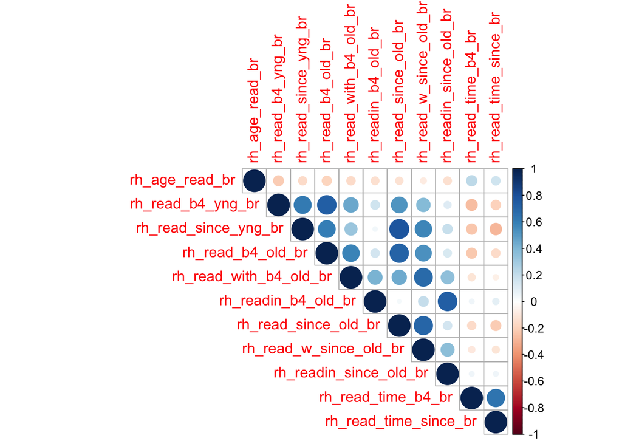

#### Bloco Pré Pandemia

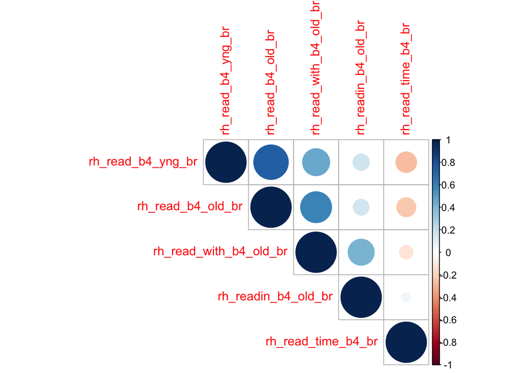

#### Bloco Pós Pandemia

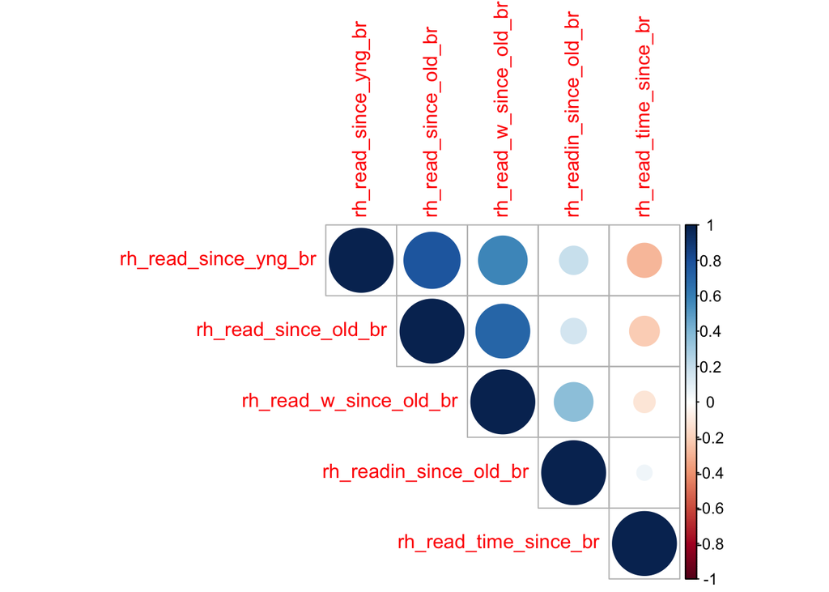

### **Multiple Correspondence Analysis**

O MCA geralmente é usado para analisar um conjunto de dados de uma pesquisa. O objetivo é identificar:

1 - Um grupo de indivíduos com perfil semelhante em suas respostas às perguntas

2 - As associações entre categorias de variáveis

Calcular e visualizar a análise de correspondência múltipla no software R usando *FactoMineR* (para a análise) e *factoextra* (para visualização de dados).

Revelar as variáveis mais importantes que mais contribuem para explicar as variações no conjunto de dados explicando como prever os resultados para indivíduos e variáveis suplementares. Filtrar os resultados do MCA para manter apenas as variáveis que mais contribuíram.

### **Multiple Correspondence Analysis**

```
##  rh_read_b4_yng_br rh_read_b4_old_br rh_read_with_b4_old_br rh_readin_b4_old_br
##  0: 58             0: 69             0:152                  0:227
##  1:143             1:159             1:135                  1:118
##  2:145             2:143             2:134                  2: 78
##  3: 56             3: 64             3: 54                  3: 39
##  4:151             4:112             4: 98                  4: 93
##  5: 50             5: 40             5: 23                  5: 27
##  6: 12             6: 28             6: 19                  6: 33
##  rh_read_time_b4_br
##  1      :376
##  2      :138
##  8      : 60
##  3      : 23
##  7      : 10
##  4      :  4
##  (Other):  4
```

[figure not shown]

> Construindo o MCA

As variáveis podem ser representadas calculando as razões de correlação entre as coordenadas dos indivíduos em um componente e cada uma das categorias.

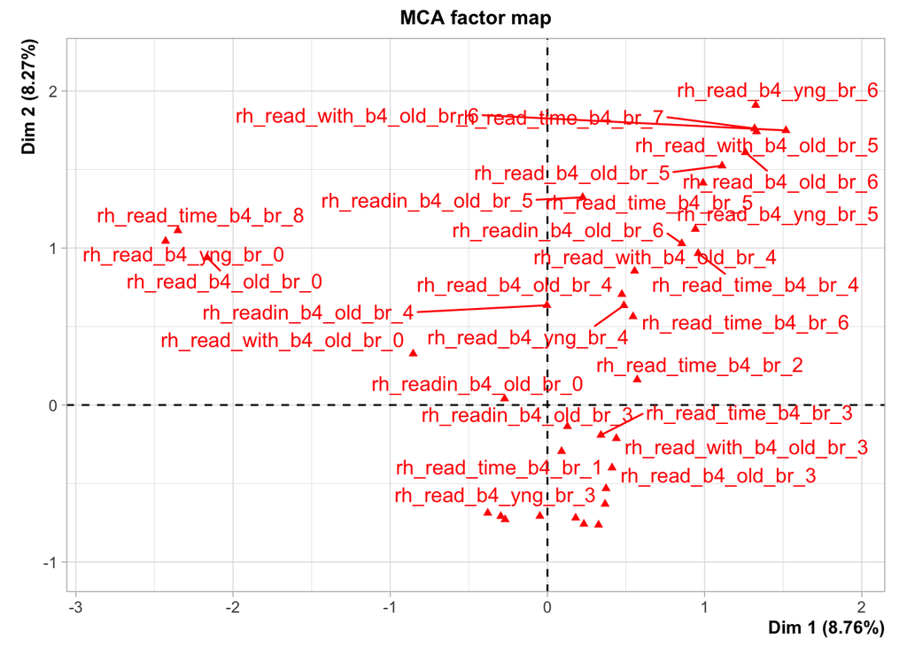

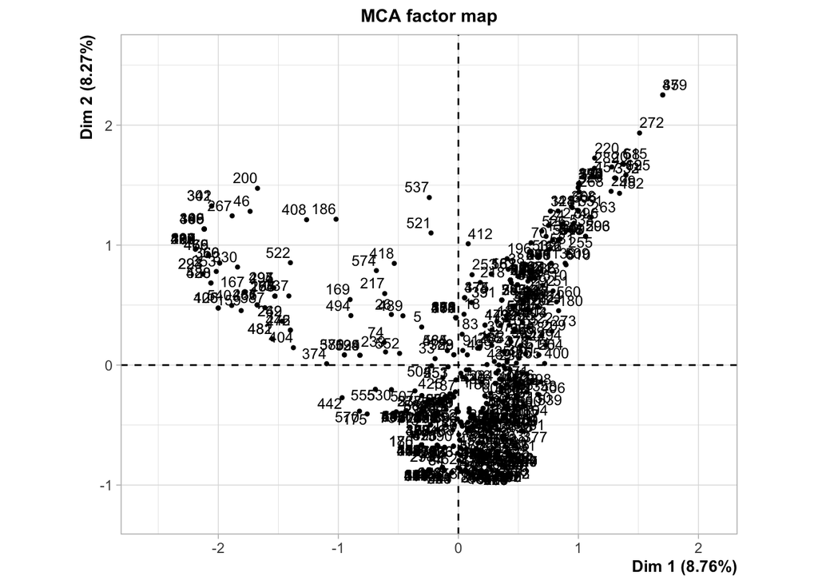

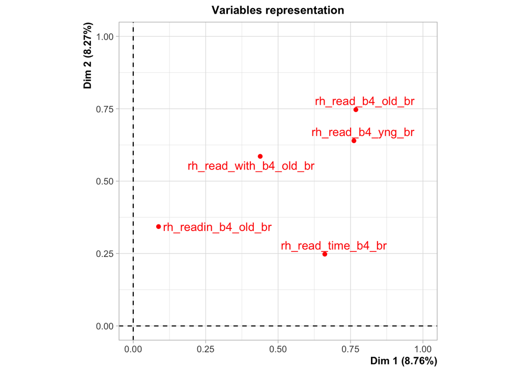

> Visualização e interpretação

Estudar a inércia dos componentes principais permite-nos, por um lado, ver se as variáveis estão estruturadas (presença de correlações entre variáveis) e, além disso, determinar o número de componentes a serem interpretados.

Os resultados em abaixo, produzidos em um gráfico de barras, correspondem ao autovalor (ou seja, a inércia ou a variação explicada) associada a cada um dos componentes; a porcentagem de inércia associada a cada componente e a soma cumulativa dessas porcentagens.

> Porcentagens de inércia explicadas por cada dimensão MCA

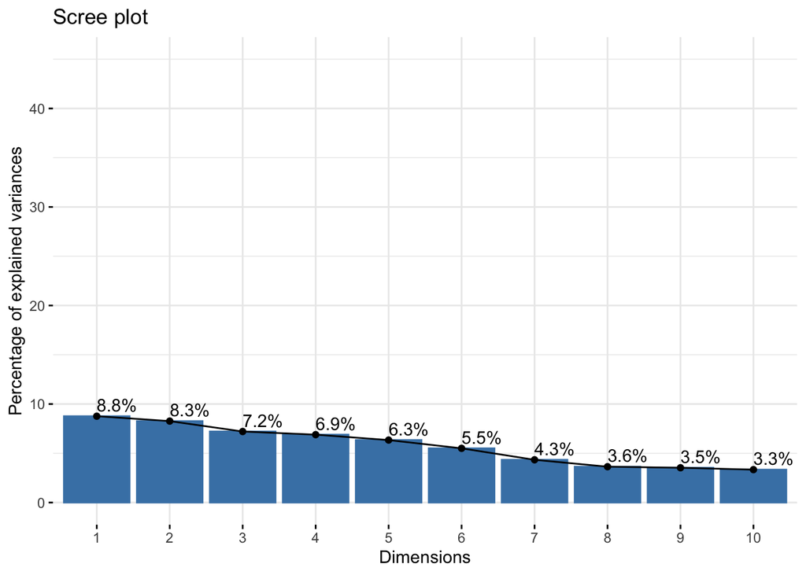

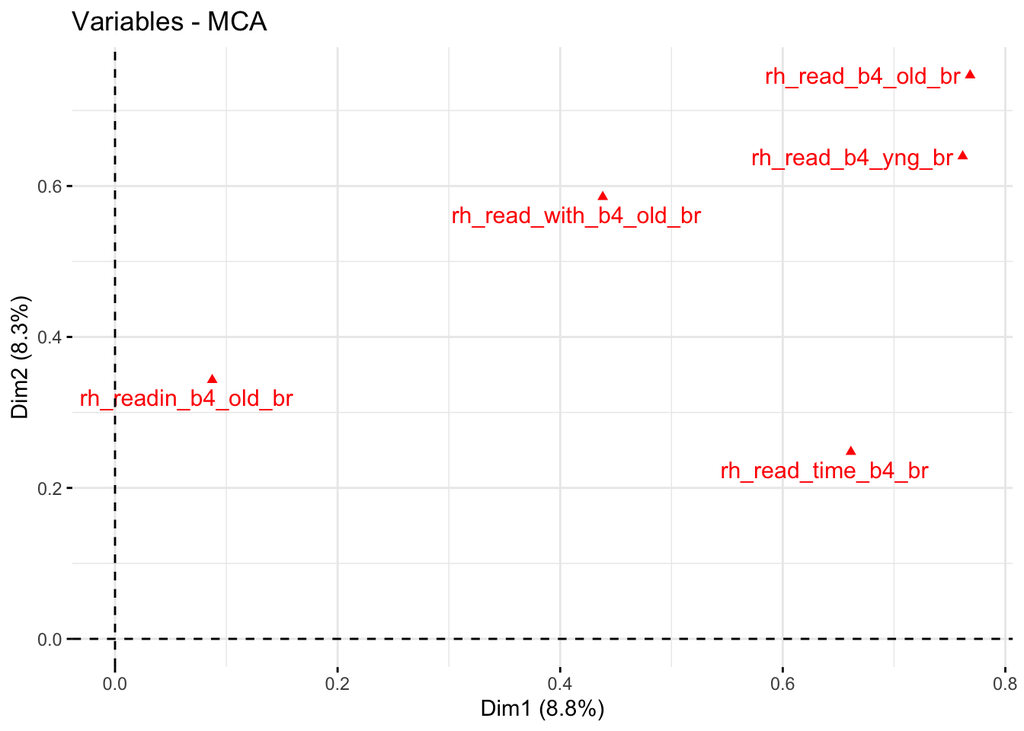

```
##                     Dim 1 Dim 2 Dim 3 Dim 4 Dim 5
## rh_read_b4_yng_br_0 -2.43  1.04  0.18  0.00  0.48
## rh_read_b4_yng_br_1 -0.30 -0.71  0.22  0.36 -1.10
## rh_read_b4_yng_br_2  0.18 -0.72  0.28  0.04  0.78
## rh_read_b4_yng_br_3  0.37 -0.53 -0.28 -0.55  1.02
```

Se uma categoria de variável é bem representada por duas dimensões, a soma do cos2 é próxima de um. Para alguns dos itens de linha, são necessárias mais de 2 dimensões para representar perfeitamente os dados.

> OS COSSENOS SAO MUITO BAIXOS!

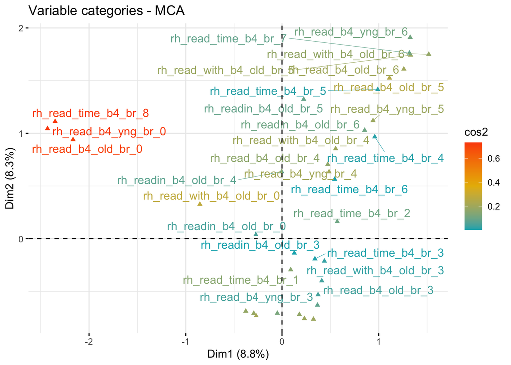

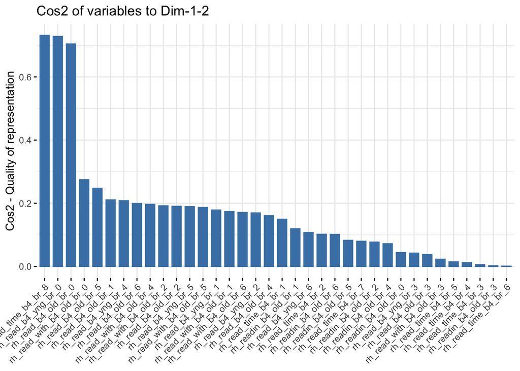

```
##                          Dim 1 Dim 2 Dim 3 Dim 4 Dim 5
## rh_read_b4_yng_br_0      20.49  4.01  0.14  0.00  1.12
## rh_read_b4_yng_br_1       0.75  4.55  0.49  1.38 14.42
## rh_read_b4_yng_br_2       0.28  4.76  0.84  0.02  7.26
## rh_read_b4_yng_br_3       0.47  1.00  0.31  1.28  4.83
## rh_read_b4_yng_br_4       2.14  3.86 12.46  0.06  0.36
## rh_read_b4_yng_br_5       2.65  3.98  9.90  5.05  0.60
## rh_read_b4_yng_br_6       1.26  2.78  0.77 11.55  0.16
## rh_read_b4_old_br_0      19.36  3.87  0.24  0.00  1.57
## rh_read_b4_old_br_1       0.69  5.37  0.67  1.42 15.80
## rh_read_b4_old_br_2       0.46  5.22  0.59  0.01  9.71
## rh_read_b4_old_br_3       0.65  0.65  1.03  1.19  4.81
## rh_read_b4_old_br_4       1.50  3.54 16.36  0.93  1.21
## rh_read_b4_old_br_5       2.96  5.90 11.72  8.01  1.23
## rh_read_b4_old_br_6       2.66  4.60  1.18 19.46  0.46
## rh_read_with_b4_old_br_0  6.64  1.03  0.04  0.10  1.71
## rh_read_with_b4_old_br_1  1.16  4.05  0.71  1.62 11.69
## rh_read_with_b4_old_br_2  0.85  4.96  0.15  0.04  5.59
## rh_read_with_b4_old_br_3  0.62  0.15  0.35  1.22  2.26
## rh_read_with_b4_old_br_4  1.80  4.54 11.77  0.47  1.70
## rh_read_with_b4_old_br_5  2.44  4.43 12.15  6.93  1.33
## rh_read_with_b4_old_br_6  2.62  3.69  1.23 18.54  0.71
## rh_readin_b4_old_br_0     1.01  0.02  0.06  0.15  0.50
## rh_readin_b4_old_br_1     0.02  3.75  0.57  0.27  1.45
## rh_readin_b4_old_br_2     0.63  1.97  0.00  0.17  1.99
## rh_readin_b4_old_br_3     0.04  0.05  0.64  0.81  0.75
## rh_readin_b4_old_br_4     0.00  2.38  7.31  0.05  3.03
## rh_readin_b4_old_br_5     0.08  3.00  3.94  5.39  0.45
## rh_readin_b4_old_br_6     1.44  2.22  2.66  4.24  0.72
## rh_read_time_b4_br_1      0.18  2.08  0.13  0.01  0.69
## rh_read_time_b4_br_2      2.70  0.23  0.10  1.16  0.30
## rh_read_time_b4_br_3      0.16  0.05  0.80  0.04  0.02
## rh_read_time_b4_br_4      0.22  0.24  0.27  1.38  0.73
## rh_read_time_b4_br_5      0.18  0.38  0.03  0.76  0.21
## rh_read_time_b4_br_6      0.02  0.02  0.27  0.01  0.00
## rh_read_time_b4_br_7      1.04  1.97  0.11  6.29  0.01
## rh_read_time_b4_br_8     19.85  4.71  0.02  0.00  0.65
```